# Estimate Robustness of Real Networks

Andrew L Jackson, Jean-Francois Arnoldi, Sam P. Ross & Ian Donohue

30 March 2020

```r
library(tidyverse)
library(furrr) # for parallel implmenetation of purrr
```

## Import the Web of Life data

Loop over the datasets and import them into a list.

```r
# get all file names in the folder data/
all_files <- dir("data/")

# find the indices that are README or reference files
remove_these <- c(grep("README", all_files), grep("references", all_files))

# remove them from the vector of names and prepend the data/ folder address
all_web_files <- paste0("data/", all_files[-remove_these])

# import all the webs and covert then to binary association form
all_webs <- map(all_web_files, ~sign(read.csv(.x)))

# add names to each of the list entries. Required by map()
names(all_webs) <- all_web_files

# a table of all the webs by type
n_types <- table(unlist(map(names(all_webs), ~substr(.x, 8, 9))))
```

We used all the available bipartite webs from http://www.web-of-life.es as downloaded on 18 Febrary 2020. These comprise:

- AF = Anemone-Fish (n = 17)
- HP = Host-Parasite (n = 51)
- PA = Plant-Ant (n = 4)
- PH = Plant-Herbivore (n = 4)
- PL = Plant-Pollinator (n = 148)
- SD = Seed dispersal (n = 34)

## Summary statistics

### Define some functions that we will use to generate summary statics

A function to calculate complexity for a given web.

```r
complexityEstimate <- function(A) {

  # rows are traits
  N <- nrow(A)

  # columns are species
  S <- ncol(A)

  # original complexity estimate
  c <- (N / sum(A)) * log(S)

  # new complexity estimate 3/Feb/2020
  # c <- N * log(N) / sum(A)

  # 6/feb/2020
  log_q <- -log ( (S * N - sum(A)) / (S * N))
  c <- (1/S) * (log(N) / log_q)

  return(c)

}
```

A function to calculate fragility.

fragility f=-log(N)/(q)/S where q=1-p and p is the connectance estimated as p~#links/(SxN). I wrote this more cleanly in overleaf.

```r
fragilityEstimate <- function(A) {

  # rows are traits
  N <- nrow(A)

  # columns are species
  S <- ncol(A)

  # connectance measures
  p <- sum(A) / (S * N)
  q <-  1 - p

  # fragility
  f <- (1/S) * (-log(N) / log(q))

  return(f)

}
```

A function to calculate the robustness of a given web.

```r
robustness <- function(Aperm, S = ncol(Aperm)){

   # number of Species
  # S <- ncol(Aperm)

  # number of traits
  # N <- nrow(Aperm)

  nn <- 0
  mm <- 0

  while (mm==0 & nn <= S) {
    nn <- nn + 1
    # mm <- min(rowSums( matrix(Aperm[, 1:nn], nrow = N, ncol = nn) ))
    mm <- min(rowSums( as.matrix(Aperm[, 1:nn])))
  }

  return( (S-nn+1) / (S * 1.0))
}
```

A function to take a given web, repeatedly resample it and remove species until it breaks. This lets us create an estimate of the mean robustness of a given web given random extinctions.

```r
shuffleExinctionSingle <- function(A, S) {

  # generate a permuation for species in A
  species <- sample(S)

  # premute within rows
  Aperm <- A[,species]

  # calculate robustness
  rob <- robustness(Aperm)

  return(rob)

}

sampleRobustness <- function(A, S = ncol(A), nb = 10){

  # number of Species
  # S <- ncol(A)

  # no longer need to prep this as we use map()
  # vector of results
  # res <- numeric(nb)

  # loop over replicates using parallel furrr map function.
  res <- future_map_dbl(1:nb, ~shuffleExinctionSingle( A, S))


  # for (k in 1:nb) {
  #
  #   rob <- shuffleExinctionSingle(A = A, S = S)
  #
  #   res[k] <- rob
  #
  # }

  # return the mean of the results vector which is mean of
  return(mean(res))

}
```

### Apply our functions to each web

Calculate some summary statistics on each web and conver to data.frame format.

```r
df_webs <-  all_webs %>%
  map_df(~data.frame(S = as.numeric(ncol(.x)),
                     N = as.numeric(nrow(.x)),
                     sum_A = as.numeric(sum(.x)),
                     min_S_per_N = min(rowSums(.x)),
                     var_S_per_N = var(rowSums(.x)),
                     mean_S_per_N = mean(rowSums(.x)),
                     est_p = sum(.x) / (ncol(.x) * nrow(.x)),
                     complexity = complexityEstimate(.x),
                     fragility = fragilityEstimate(.x)
                     )
         )

# calculate dispersion, where the expected value according to the binomial
# distributio is 1.
df_webs <- df_webs %>% mutate(dispersion = var_S_per_N / mean_S_per_N * (1 / 1 - est_p))


 # test_traits[i] <- min(rowSums(tmp))
 #  var_traits[i] <- var(rowSums(tmp))
 #  mean_traits[i] <- mean(rowSums(tmp))
 #  est_p[i] <- sum(tmp) / (res_S[i] * res_N[i])
 #  dispersion_test[i] <- (var_traits[i] / mean_traits[i]) * (1/(1-est_p[i]))


# print(df)
```

## Simulate Extinctions to calculate robustness

```r
# set up the multicore for the function sampleRobustness which calls them.
# im not sure if i should do this within sampleRobustness or if its ok to
# do it once here outside.
plan(multisession(workers = 3))
```

```r
do_robustness <- FALSE

if (do_robustness == TRUE ) {

  robustness_results <- all_webs %>%
    map_dbl(~sampleRobustness(.x, nb = 500))

  save(robustness_results, file = "robustness_run.rda", compress = "xz")


}

if (do_robustness == FALSE){
  print("NB sampling for robustness not run. Loaded instead from previous run.")
  load("robustness_run.rda")
}
```

```
[1] "NB sampling for robustness not run. Loaded instead from previous run."
```

```r
# Add the robustness estimate to the data.frame and
# calcuate the residual to Jeff's model
df_webs <- df_webs %>%
  mutate(robustness = robustness_results)

df_webs <- df_webs %>%
  mutate(residual =
           robustness - ( 0.7*exp(-3.5*complexity**2)+.3*exp(-0.8*complexity))
         )

# add labels for each type of web
df_webs <- df_webs %>% mutate(type = unlist(map(names(all_webs), ~substr(.x, 8, 9))))
```

## Plot results

new_c <- seq(0, 2.5, length = 100)

# est_r <- 0.7*exp(-3.5*new_c**2)+.3*exp(-0.8*new_c)

# new approximation 3/Feb/2020

fit_df <- data.frame(new_c = new_c, est_r = est_r)

g1 <- ggplot(df_webs %>% filter(N <= Inf), aes(x = complexity, y = robustness, color = log10(dispersion))) + geom_point() + scale_color_viridis_c() + geom_line(data = fit_df, mapping = aes(x = new_c, y = est_r, color = NULL))

print(g1)

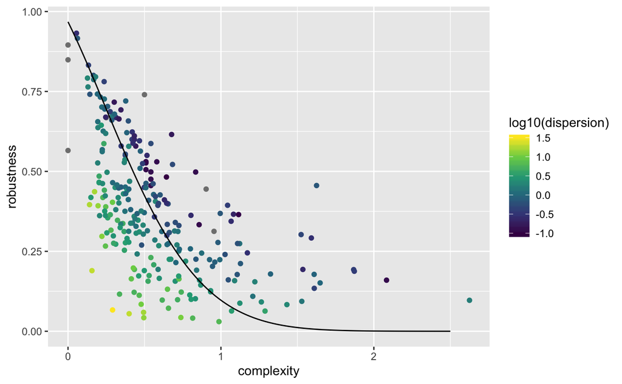

[figure not shown]

g3 <- ggplot(df_webs, aes(x = log10(dispersion), y = residual, color = type )) + geom_point(aes(shape = type)) + scale_color_viridis_c() + geom_hline(yintercept = 0) + labs(color = expression(log10), shape = Type)

print(g3)

```
Error: Discrete value supplied to continuous scale
```

g4 <- ggplot(df_webs, aes(x = log10(dispersion), y = residual, color = type)) + geom_point(aes(shape = type), size = 2) + scale_color_viridis_d() + geom_hline(yintercept = 0) + labs(color = expression(log10), shape = Type)

print(g4)

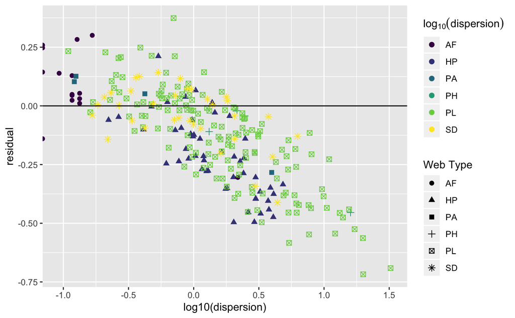

# ggsave(g4,filename = -dispersion.jpeg, width = 10, height = 7)

g5 <- ggplot(df_webs %>% filter(N <= Inf), aes(x = complexity, y = robustness, color = type)) + geom_point(aes(shape = type), size = 4) + scale_color_viridis_d() + geom_line(data = fit_df, mapping = aes(x = new_c, y = est_r, color = NULL))

print(g5)

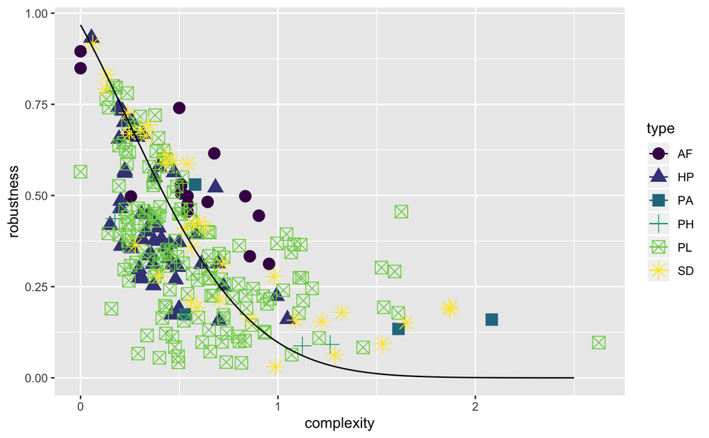

# ggsave(g5,filename = -complexity.jpeg, width = 10, height = 7)

## Fit linear models

df_webs <- df_webs %>% mutate(robustness_hat = (N_vec * (exp(-complexity - beta * complexity ^ 2 )) ) / (N_vec + 1))

# analytical_model <- with( df_webs,

# (exp(-complexity - beta * complexity ^ 2 )) ) /

# (N_vec + 1)}

# null model

m0 <- lm(robustness ~1, data = df_webs %>% filter(!is.na(dispersion) & (dispersion > 0)))

# model as above with analytical model as offset

m1 <- lm(robustness ~ -1, offset = robustness_hat, data = df_webs %>% filter(!is.na(dispersion) & (dispersion > 0)))

# model as above including log10(dispersion) as covariate

m2 <- lm(robustness ~ I(log10(dispersion)), offset = robustness_hat, data = df_webs %>% filter(!is.na(dispersion) & (dispersion > 0)))

# model as above including web type as covariate

m3 <- lm(robustness ~ I(log10(dispersion)) + factor(type), offset = robustness_hat, data = df_webs %>% filter(!is.na(dispersion) & (dispersion > 0)))